# Module 2 Assignment

Sakshi Mude

MPS Analytics, Northeastern University

ALY 6020 – Predictive Analytics

Prof. Vladimir Shapiro

March 3, 2023

## Introduction

The automotive industry has been rapidly evolving over the years, with advancements in technology and a growing focus on environmental sustainability. As a result, car manufacturers are increasingly under pressure to design vehicles that are energy-efficient and environmentally friendly. In this analysis, we will be working with a car manufacturer known for producing large automobiles, who is struggling with sales and has approached us to help design a more fuel-efficient car. Using data gathering techniques, we will identify which attributes contribute to higher gas mileage and provide insights to the manufacturer on how they can design a more energy-efficient automobile. The ultimate goal of this analysis is to help the manufacturer improve their sales and contribute to a more sustainable future.

This assignment aims to investigate the data cleaning techniques essential for preparing the dataset while preserving its authenticity for the target audience. The dataset will be examined and cleansed to develop a model that can provide meaningful insights to the automobile manufacturer. The model's outcomes will help to design the best model possible for the company. The assignment is structured into three parts, with each section covering several steps necessary for linear regression. In the first section, we will import the dataset and cleanse it to ensure precise results. In the second section, we will apply the linear regression model to the cleansed dataset to identify the attributes that significantly impact car MPG and suggest ways to improve them. The final phase will refine the model using selection procedures to evaluate its effectiveness. Based on the refined model, we will conclude the optimal factor for a fuel-efficient car for the company.

```python
pip install mlxtend
```

```python
import numpy as np
import pandas as pd
import matplotlib.pyplot as plt
import seaborn as sns
from sklearn import linear_model
from sklearn.metrics import mean_squared_error, r2_score
from sklearn.model_selection import train_test_split
from sklearn.linear_model import LinearRegression
import statsmodels.api as sm
from scipy import stats
import warnings
warnings.filterwarnings('ignore')
%matplotlib inline
from matplotlib.pyplot import xticks
import mlxtend
from mlxtend.feature_selection import SequentialFeatureSelector as SFS
from sklearn.metrics import accuracy_score as acc
```

### Data Cleaning

To construct the model, the primary focus of the assignment is to cleanse the dataset by retaining only necessary data and removing redundant information. The initial step involves importing the CSV formatted dataset into Jupyter notebook using the Pandas library for Python. Following the importation, it is crucial to assess the dataset's format and type, which can be achieved by printing it out and identifying the columns containing data on displacement, cylinders, weight, horsepower, acceleration, and model year. By employing Python's dtypes and shape functions, the characteristics of each column can be determined, and it can be determined that the dataset contains 398 rows and 8 columns of three distinct data types: integers, decimals, and objects. Before using the model, the dataset must be cleansed by ensuring that the correct data type is used, null values are replaced with the mean, mode, or median, and irrelevant columns that may not affect the results are removed.

```python
car_data = pd.read_csv("/Users/sakshi/Downloads/CARR.csv")
car_data.head()
```

|  | MPG | Cylinders | Displacement | Horsepower | Weight | Acceleration | Model Year | US Made |
| --- | --- | --- | --- | --- | --- | --- | --- | --- |
| 0 | 18.0 | 8 | 307.0 | 130 | 3504 | 12.0 | 70 | 1 |
| 1 | 15.0 | 8 | 350.0 | 165 | 3693 | 11.5 | 70 | 1 |
| 2 | 18.0 | 8 | 318.0 | 150 | 3436 | 11.0 | 70 | 1 |
| 3 | 16.0 | 8 | 304.0 | 150 | 3433 | 12.0 | 70 | 1 |
| 4 | 17.0 | 8 | 302.0 | 140 | 3449 | 10.5 | 70 | 1 |

```python
car_data.shape
```

```
(398, 8)
```

```python
car_data.describe()
```

|  | MPG | Cylinders | Displacement | Weight | Acceleration | Model Year | US Made |
| --- | --- | --- | --- | --- | --- | --- | --- |
| count | 398.000000 | 398.000000 | 398.000000 | 398.000000 | 398.000000 | 398.000000 | 398.000000 |
| mean | 23.514573 | 5.454774 | 193.425879 | 2970.424623 | 15.568090 | 76.010050 | 0.625628 |
| std | 7.815984 | 1.701004 | 104.269838 | 846.841774 | 2.757689 | 3.697627 | 0.484569 |
| min | 9.000000 | 3.000000 | 68.000000 | 1613.000000 | 8.000000 | 70.000000 | 0.000000 |
| 25% | 17.500000 | 4.000000 | 104.250000 | 2223.750000 | 13.825000 | 73.000000 | 0.000000 |
| 50% | 23.000000 | 4.000000 | 148.500000 | 2803.500000 | 15.500000 | 76.000000 | 1.000000 |
| 75% | 29.000000 | 8.000000 | 262.000000 | 3608.000000 | 17.175000 | 79.000000 | 1.000000 |
| max | 46.600000 | 8.000000 | 455.000000 | 5140.000000 | 24.800000 | 82.000000 | 1.000000 |

```python
car_data.info()
```

```
<class 'pandas.core.frame.DataFrame'>
RangeIndex: 398 entries, 0 to 397
Data columns (total 8 columns):
 #   Column        Non-Null Count  Dtype
---  ------        --------------  -----
 0   MPG           398 non-null    float64
 1   Cylinders     398 non-null    int64
 2   Displacement  398 non-null    float64
 3   Horsepower    398 non-null    object
 4   Weight        398 non-null    int64
 5   Acceleration  398 non-null    float64
 6   Model Year    398 non-null    int64
 7   US Made       398 non-null    int64
dtypes: float64(3), int64(4), object(1)
memory usage: 25.0+ KB
```

```python
car_data.columns
```

```
Index(['MPG', 'Cylinders', 'Displacement', 'Horsepower', 'Weight',
       'Acceleration', 'Model Year', 'US Made'],
      dtype='object')
```

### Checking Null values

```python
car_data.isnull().sum()*100/car_data.shape[0]
```

```
MPG             0.0
Cylinders       0.0
Displacement    0.0
Horsepower      0.0
Weight          0.0
Acceleration    0.0
Model Year      0.0
US Made         0.0
dtype: float64
```

```python
car_data.dtypes
```

```
MPG             float64
Cylinders         int64
Displacement    float64
Horsepower       object
Weight            int64
Acceleration    float64
Model Year        int64
US Made           int64
dtype: object
```

```python
car_data.Horsepower = car_data.Horsepower.str.replace('?','NaN').astype(float)
```

```python
car_data.Horsepower.fillna(car_data.Horsepower.mean(),inplace=True)
```

```python
car_data.Horsepower = car_data.Horsepower.astype(int)
```

```python
car_data.dtypes
```

```
MPG             float64
Cylinders         int64
Displacement    float64
Horsepower        int64
Weight            int64
Acceleration    float64
Model Year        int64
US Made           int64
dtype: object
```

## Exploratory Data Analysis

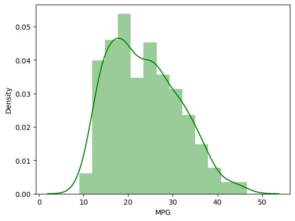

```python
# Price: Target Variable Distribution
car_data.MPG.describe()
sns.distplot(car_data['MPG'], color = 'green')
```

[figure not shown]

```python
plot1 = sns.countplot(car_data['MPG'])
plot1.set(xlabel = 'MPG', ylabel= 'Horsepower')
plt.show()
plt.tight_layout()
```

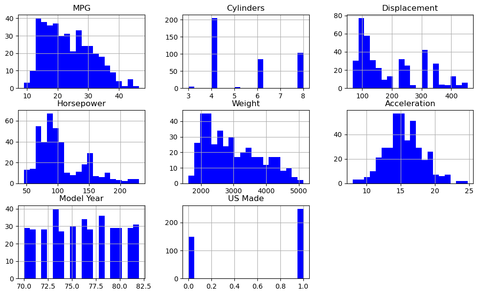

```python
car_data.hist(figsize=(12,7),bins=20, color="blue")
plt.show()
```

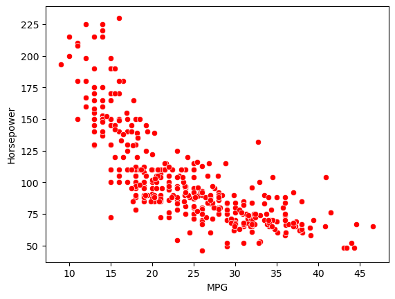

```python
plot2 = sns.scatterplot(x = 'MPG', y = 'Horsepower', data = car_data, color = 'red')
plot2.set_xlabel('MPG')
plot2.set_ylabel('Horsepower')
plt.show()
```

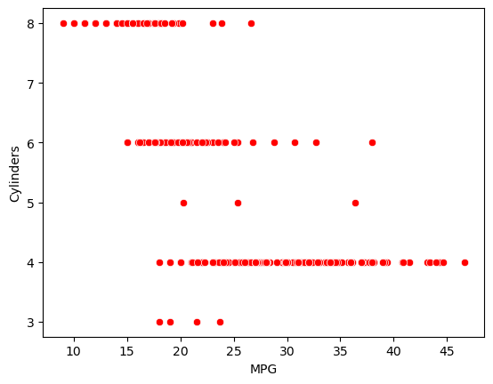

```python
plot3 = sns.scatterplot(x = 'MPG', y = 'Cylinders', data = car_data, color = 'red')
plot3.set_xlabel('MPG')
plot3.set_ylabel('Cylinders')
plt.show()
```

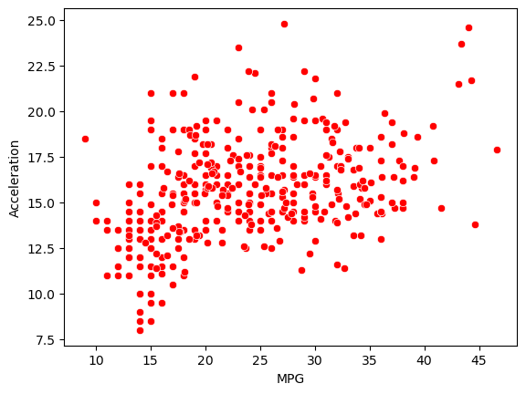

```python
plot4 = sns.scatterplot(x = 'MPG', y = 'Acceleration', data = car_data,color = 'red')
plot4.set_xlabel('MPG')
plot4.set_ylabel('Acceleration')
plt.show()
```

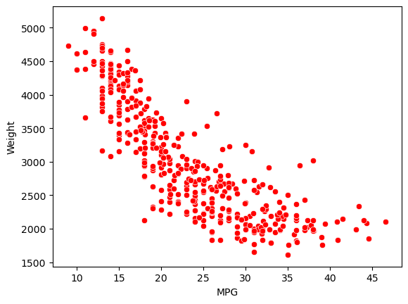

```python
plot5 = sns.scatterplot(x = 'MPG', y = 'Weight', data = car_data, color = 'red')
plot5.set_xlabel('MPG')
plot5.set_ylabel('Weight')
plt.show()
```

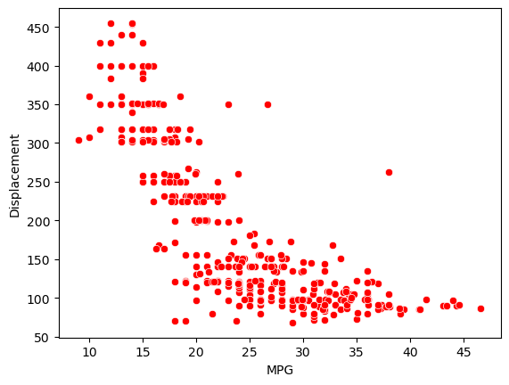

```python
plot6 = sns.scatterplot(x = 'MPG', y = 'Displacement', data = car_data, color = 'red')
plot6.set_xlabel('MPG')
plot6.set_ylabel('Displacement')
plt.show()
```

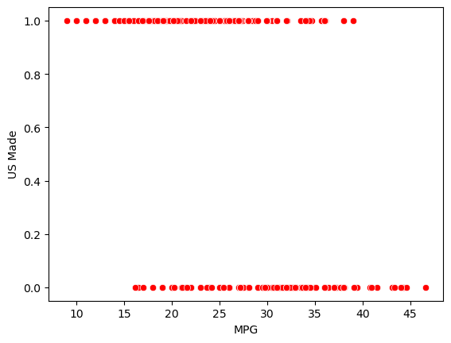

```python
plot7 = sns.scatterplot(x = 'MPG', y = 'US Made', data = car_data, color = 'red')
plot7.set_xlabel('MPG')
plot7.set_ylabel('US Made')
plt.show()
```

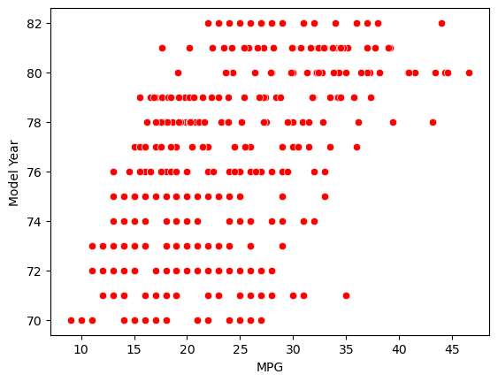

```python
plot8 = sns.scatterplot(x = 'MPG', y = 'Model Year', data = car_data, color = 'red')
plot8.set_xlabel('MPG')
plot8.set_ylabel('Model Year')
plt.show()
```

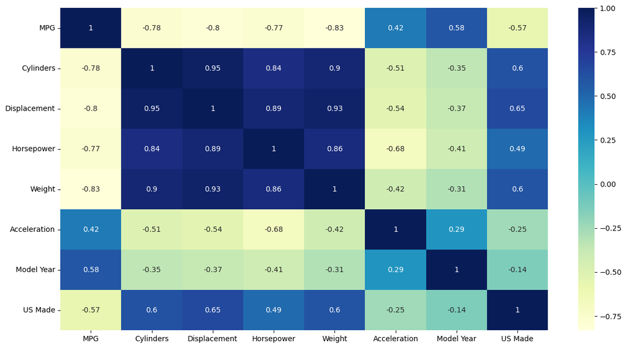

```python
plt.figure(figsize=(15,8))
sns.heatmap(car_data.corr(), annot=True, cmap="YlGnBu")
```

#### Splitting the Data

To construct the model, the dataset was split into two distinct groups. The first group solely contained MPG, which is the dependent variable, while the other group consisted of additional car features, the independent variables. Subsequently, the dataset was partitioned into a train and test set to carry out the regression analysis. The linear regression technique will be utilized to identify the variables that have a greater effect on the car's MPG now that we have a train and test dataset that was separated using an 8:2 ratio.

### Modelling

```python
X = car_data.drop(['MPG'], axis=1)
Y = car_data["MPG"]
```

```python
X_Train, X_Test,Y_Train, Y_Test = train_test_split(X, Y, test_size=0.2, random_state = 101)
```

```python
X_Train_sm = sm.add_constant(X_Train)
X_Train_sm.head()
```

|  | const | Cylinders | Displacement | Horsepower | Weight | Acceleration | Model Year | US Made |
| --- | --- | --- | --- | --- | --- | --- | --- | --- |
| 57 | 1.0 | 4 | 113.0 | 95 | 2278 | 15.5 | 72 | 0 |
| 389 | 1.0 | 6 | 232.0 | 112 | 2835 | 14.7 | 82 | 1 |
| 320 | 1.0 | 4 | 119.0 | 92 | 2434 | 15.0 | 80 | 0 |
| 357 | 1.0 | 4 | 119.0 | 100 | 2615 | 14.8 | 81 | 0 |
| 160 | 1.0 | 6 | 231.0 | 110 | 3907 | 21.0 | 75 | 1 |

```python
mode = sm.OLS(Y_Train, X_Train_sm).fit()
```

```python
print(mode.summary())
```

```
                            OLS Regression Results
==============================================================================
Dep. Variable:                    MPG   R-squared:                       0.828
Model:                            OLS   Adj. R-squared:                  0.824
Method:                 Least Squares   F-statistic:                     213.4
Date:                Sat, 04 Mar 2023   Prob (F-statistic):          1.63e-114
Time:                        17:19:30   Log-Likelihood:                -826.29
No. Observations:                 318   AIC:                             1669.
Df Residuals:                     310   BIC:                             1699.
Df Model:                           7
Covariance Type:            nonrobust
================================================================================
                   coef    std err          t      P>|t|      [0.025      0.975]
--------------------------------------------------------------------------------
const          -16.8943      5.014     -3.369      0.001     -26.760      -7.029
Cylinders       -0.6712      0.355     -1.891      0.059      -1.369       0.027
Displacement     0.0314      0.009      3.647      0.000       0.014       0.048
Horsepower      -0.0183      0.015     -1.249      0.213      -0.047       0.011
Weight          -0.0072      0.001     -9.497      0.000      -0.009      -0.006
Acceleration     0.0867      0.108      0.799      0.425      -0.127       0.300
Model Year       0.8108      0.056     14.603      0.000       0.702       0.920
US Made         -2.5715      0.517     -4.971      0.000      -3.589      -1.554
==============================================================================
Omnibus:                       10.982   Durbin-Watson:                   1.913
Prob(Omnibus):                  0.004   Jarque-Bera (JB):               13.310
Skew:                           0.322   Prob(JB):                      0.00129
Kurtosis:                       3.767   Cond. No.                     8.40e+04
==============================================================================

Notes:
[1] Standard Errors assume that the covariance matrix of the errors is correctly specified.
[2] The condition number is large, 8.4e+04. This might indicate that there are
strong multicollinearity or other numerical problems.
```

```python
mode.rsquared*100
```

```
82.81464249433567
```

```python
print(mode.aic)
```

```
1668.583510716029
```

To produce a simpler and easily understandable model, stepwise regression is used to select the key variables when running a regression model with a lot of variables, including extra ones. Forward selection is one of two widely used stepwise regression methods. In this approach, a model with no features is initially created, and the features are gradually added in each subsequent forward step based on which feature produces the most improvement in the model. The sequential feature selection technique of the Mixtend library was used to perform forward selection for feature selection in this model.

```python
X_train, X_test, y_train, y_test = train_test_split(X,Y, test_size=.3, random_state=101)
```

```python
LinRegression = LinearRegression()

SFS1 = SFS(LinRegression,k_features =7,forward=True, floating= False, scoring="r2", verbose=2, cv=5)

SFS1.fit(X_Train,Y_Train)
```

[output not shown]

```
SequentialFeatureSelector(estimator=LinearRegression(), k_features=(7, 7),
                          scoring='r2', verbose=2)
```

```python
SFS1.subsets_
```

```
{1: {'feature_idx': (3,),
  'cv_scores': array([0.69773258, 0.63992884, 0.72483316, 0.67258668, 0.65976202]),
  'avg_score': 0.6789686554213309,
  'feature_names': ('Weight',)},
 2: {'feature_idx': (3, 5),
  'cv_scores': array([0.84081311, 0.7877958 , 0.82165309, 0.79982888, 0.78654624]),
  'avg_score': 0.8073274207625522,
  'feature_names': ('Weight', 'Model Year')},
 3: {'feature_idx': (3, 5, 6),
  'cv_scores': array([0.83736678, 0.77415434, 0.83929353, 0.81952489, 0.79461736]),
  'avg_score': 0.812991379003648,
  'feature_names': ('Weight', 'Model Year', 'US Made')},
 4: {'feature_idx': (1, 3, 5, 6),
  'cv_scores': array([0.83713021, 0.7798625 , 0.84432369, 0.82455062, 0.79748173]),
  'avg_score': 0.8166697506857075,
  'feature_names': ('Displacement', 'Weight', 'Model Year', 'US Made')},
 5: {'feature_idx': (0, 1, 3, 5, 6),
  'cv_scores': array([0.83821737, 0.78141918, 0.84384396, 0.82851045, 0.79825151]),
  'avg_score': 0.8180484948739188,
  'feature_names': ('Cylinders',
   'Displacement',
   'Weight',
   'Model Year',
   'US Made')},
 6: {'feature_idx': (0, 1, 2, 3, 5, 6),
  'cv_scores': array([0.84424782, 0.76253601, 0.8439451 , 0.8281009 , 0.80455116]),
  'avg_score': 0.8166761989350368,
  'feature_names': ('Cylinders',
   'Displacement',
   'Horsepower',
   'Weight',
   'Model Year',
   'US Made')},
 7: {'feature_idx': (0, 1, 2, 3, 4, 5, 6),
  'cv_scores': array([0.84343134, 0.75730213, 0.84115458, 0.82463812, 0.80539193]),
  'avg_score': 0.8143836196420086,
  'feature_names': ('Cylinders',
   'Displacement',
   'Horsepower',
   'Weight',
   'Acceleration',
   'Model Year',
   'US Made')}}
```

```python
SFS1.get_metric_dict()
```

```
{1: {'feature_idx': (3,),
  'cv_scores': array([0.69773258, 0.63992884, 0.72483316, 0.67258668, 0.65976202]),
  'avg_score': 0.6789686554213309,
  'feature_names': ('Weight',),
  'ci_bound': 0.03808180469362892,
  'std_dev': 0.02962893781571238,
  'std_err': 0.01481446890785619},
 2: {'feature_idx': (3, 5),
  'cv_scores': array([0.84081311, 0.7877958 , 0.82165309, 0.79982888, 0.78654624]),
  'avg_score': 0.8073274207625522,
  'feature_names': ('Weight', 'Model Year'),
  'ci_bound': 0.026936494996152523,
  'std_dev': 0.020957508228273983,
  'std_err': 0.010478754114136991},
 3: {'feature_idx': (3, 5, 6),
  'cv_scores': array([0.83736678, 0.77415434, 0.83929353, 0.81952489, 0.79461736]),
  'avg_score': 0.812991379003648,
  'feature_names': ('Weight', 'Model Year', 'US Made'),
  'ci_bound': 0.032386120213568015,
  'std_dev': 0.02519750178910318,
  'std_err': 0.01259875089455159},
 4: {'feature_idx': (1, 3, 5, 6),
  'cv_scores': array([0.83713021, 0.7798625 , 0.84432369, 0.82455062, 0.79748173]),
  'avg_score': 0.8166697506857075,
  'feature_names': ('Displacement', 'Weight', 'Model Year', 'US Made'),
  'ci_bound': 0.03131699082633785,
  'std_dev': 0.02436568280399891,
  'std_err': 0.012182841401999456},
 5: {'feature_idx': (0, 1, 3, 5, 6),
  'cv_scores': array([0.83821737, 0.78141918, 0.84384396, 0.82851045, 0.79825151]),
  'avg_score': 0.8180484948739188,
  'feature_names': ('Cylinders',
   'Displacement',
   'Weight',
   'Model Year',
   'US Made'),
  'ci_bound': 0.031035290290408964,
  'std_dev': 0.02414651021675317,
  'std_err': 0.012073255108376583},
 6: {'feature_idx': (0, 1, 2, 3, 5, 6),
```

[output cut: 9 more lines]

```
  'std_dev': 0.030700121515932866,
  'std_err': 0.015350060757966431},
 7: {'feature_idx': (0, 1, 2, 3, 4, 5, 6),
  'cv_scores': array([0.84343134, 0.75730213, 0.84115458, 0.82463812, 0.80539193]),
  'avg_score': 0.8143836196420086,
  'feature_names': ('Cylinders',
   'Displacement',
   'Horsepower',
   'Weight',
   'Acceleration',
   'Model Year',
   'US Made'),
  'ci_bound': 0.04066379346033427,
  'std_dev': 0.03163781279485378,
  'std_err': 0.01581890639742689}}
```

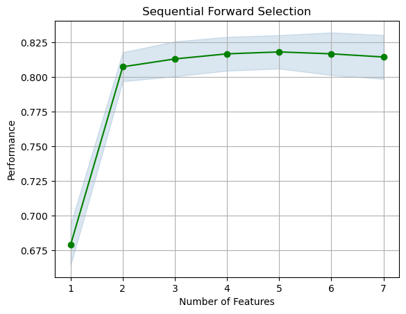

```python
from mlxtend.plotting import plot_sequential_feature_selection as plot_sfs
fig1 = plot_sfs(SFS1.get_metric_dict(confidence_interval=0.95), kind='std_err', color = 'green')

plt.title('Sequential Forward Selection')
plt.grid()
plt.show()
```

## Conclusion

Based on the data presented in Plot 5 and 6, it appears that there is an inverse correlation between the weight and MPG of the car. As the weight increases, the MPG decreases because the car requires more power, which in turn uses more fuel. A similar trend is observed with "Displacement," which also negatively affects MPG. The number of cylinders also plays a role in this relationship, with higher cylinder counts leading to lower MPG due to increased fuel consumption. Acceleration does not seem to have a significant impact on MPG, but there are some scenarios where higher acceleration correlates with higher MPG.

According to the forward selection model, the five most important parameters for developing a fuel-efficient car are cylinders, displacement, weight, model year, and country of origin. However, manufacturers should also consider other factors such as wheel design, aerodynamics, seating capacity, and other elements that may indirectly impact the car's performance.

## References

1. Real Python. (2022a, May 24). Linear Regression in Python. Retrieved March 3rd, 2023, from https://realpython.com/linear-regression-in-python/
2. Toth, G. (2020, December 23). Feature selection methods with Python. DataSklr. March 3rd, 2023, from https://www.datasklr.com/ols-least-squares- regression/variable-selection/
3. How to Fit a Linear Regression Model in Python? (2021, July 29). Analyticssteps. March 3rd, 2023, from https://www.analyticssteps.com/blogs/how-fit-linear- regression-model-python/